# Business Statistics End of Term Assessment IB94X0 2021-2022 #1

2152449

This is to certify that the work I am submitting is my own. All external references and sources are clearly acknowledged and identified within the contents. I am aware of the University of Warwick regulation concerning plagiarism and collusion.

No substantial part(s) of the work submitted here has also been submitted by me in other assessments for accredited courses of study, and I acknowledge that if this has been done an appropriate reduction in the mark I might otherwise have received will be made.

I declare that this work is entirely my own in accordance with the University’s Regulation 11 and the WBS guidelines on plagiarism and collusion. All external references and sources are clearly acknowledged and identified within the contents. No substantial part(s) of the work submitted here has also been submitted by me in other assessments for accredited courses of study, and I acknowledge that if this has been done it may result in me being reported for self-plagiarism and an appropriate reduction in marks may be made when marking this piece of work.

# Question 1 (Section 1)

## Data Dictionary

Below is a collection of data samples and its description.

| Variable | Description |
| --- | --- |
| student_ID | ID of the student |
| tutoring | Indication of students who have received tutoring |
| absences | Proportion of class time missed |
| score.t1 | Student’s score at the beginning of the academic year |
| score.t2 | Student’s score at the end of the academic year |

```r
# To load the necessary libraries
library(tidyverse)
library(ggplot2)
library(Hmisc)
library(plyr)
library(gapminder)
library(dplyr)
library(emmeans)
library(grid)
library(gridExtra)
library(car)
```

## Load, View and Factorise Data

```r
# To read the data file
tutoring_data <- read_csv("tutoring_test_data.csv")
# To view the data types
str(tutoring_data)
```

```
## spec_tbl_df [202 × 5] (S3: spec_tbl_df/tbl_df/tbl/data.frame)
##  $ student_ID: num [1:202] 56 40 63 108 72 10 15 42 152 104 ...
##  $ tutoring  : logi [1:202] TRUE TRUE TRUE FALSE TRUE TRUE ...
##  $ absences  : num [1:202] 3.6 2.4 3.6 4.8 4.8 ...
##  $ score.t1  : num [1:202] 70.4 67.8 40.2 75.3 31 ...
##  $ score.t2  : num [1:202] 75.2 75.9 45.5 79.7 31.7 ...
##  - attr(*, "spec")=
##   .. cols(
##   ..   student_ID = col_double(),
##   ..   tutoring = col_logical(),
##   ..   absences = col_double(),
##   ..   score.t1 = col_double(),
##   ..   score.t2 = col_double()
##   .. )
##  - attr(*, "problems")=<externalptr>
```

```r
# To update "student_ID" and "tutoring" to factors
tutoring_data$student_ID <- factor(tutoring_data$student_ID)
tutoring_data$tutoring <- factor(tutoring_data$tutoring,
                                 levels=c("TRUE","FALSE"))

# To confirm "student_ID" and "tutoring" have been updated to factors
str(tutoring_data)
```

```
## spec_tbl_df [202 × 5] (S3: spec_tbl_df/tbl_df/tbl/data.frame)
##  $ student_ID: Factor w/ 202 levels "1","2","3","4",..: 56 40 63 108 72 10 15 42 152 104 ...
##  $ tutoring  : Factor w/ 2 levels "TRUE","FALSE": 1 1 1 2 1 1 1 1 2 2 ...
##  $ absences  : num [1:202] 3.6 2.4 3.6 4.8 4.8 ...
##  $ score.t1  : num [1:202] 70.4 67.8 40.2 75.3 31 ...
##  $ score.t2  : num [1:202] 75.2 75.9 45.5 79.7 31.7 ...
##  - attr(*, "spec")=
##   .. cols(
##   ..   student_ID = col_double(),
##   ..   tutoring = col_logical(),
##   ..   absences = col_double(),
##   ..   score.t1 = col_double(),
##   ..   score.t2 = col_double()
##   .. )
##  - attr(*, "problems")=<externalptr>
```

## Inspect and Clean Data

```r
# To check for missing and outlier data
summary(tutoring_data)
```

```
##    student_ID   tutoring      absences          score.t1        score.t2
##  1      :  1   TRUE :101   Min.   :  1.200   Min.   :17.31   Min.   : 11.92
##  2      :  1   FALSE:101   1st Qu.:  3.600   1st Qu.:46.56   1st Qu.: 46.47
##  3      :  1               Median :  6.000   Median :53.96   Median : 55.26
##  4      :  1               Mean   :  7.012   Mean   :53.89   Mean   : 56.23
##  5      :  1               3rd Qu.:  8.400   3rd Qu.:62.83   3rd Qu.: 65.01
##  6      :  1               Max.   :100.000   Max.   :88.46   Max.   :200.00
##  (Other):196                                                 NA's   :1
```

```r
# To remove the NA value from the attribute, "score.t2"
# Note, one row of data is removed, with 201 rows remaining
tutoring_data_1 <- na.omit(tutoring_data)
```

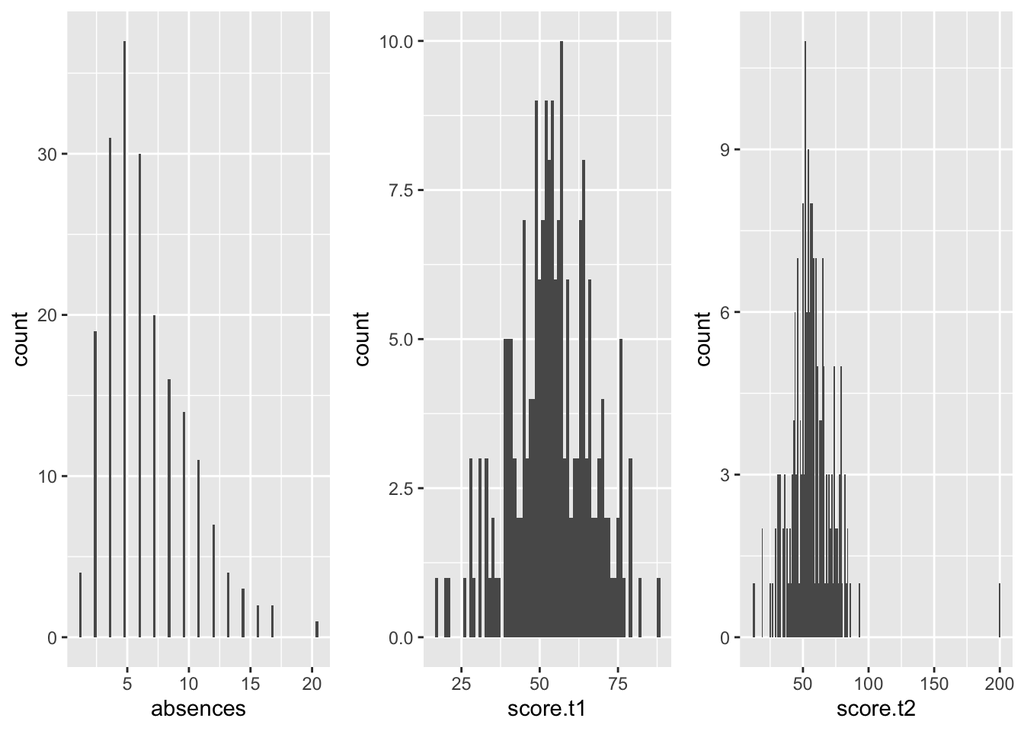

```r
## To check the distribution of the continuous, numeric data

# To examine the attribute, "absences" via a plot
# Note, no anomalies found
examine_absences <- ggplot(tutoring_data_1) +
  geom_histogram(mapping=aes(x=absences),
                 binwidth=0.2,
                 bins=count(distinct(tutoring_data_1, absences)))

# To examine the attribute, "score.t1" via a plot
# Note, no anomalies found
examine_score.t1 <- ggplot(tutoring_data_1) +
  geom_histogram(mapping=aes(x=score.t1),
                 binwidth=1,
                 bins=count(distinct(tutoring_data_1, score.t1)))

# To examine the attribute, "score.t2" via a plot
# Note, there is problematic data exceeding the maximum score of 100 permitted
examine_score.t2 <- ggplot(tutoring_data_1) +
  geom_histogram(mapping=aes(x=score.t2),
                 binwidth=1,
                 bins=count(distinct(tutoring_data_1, score.t2)))

# To arrange all the plots in a single grid for ease of data examination
grid.arrange(examine_absences,
             examine_score.t1,
             examine_score.t2,
             ncol=3)
```

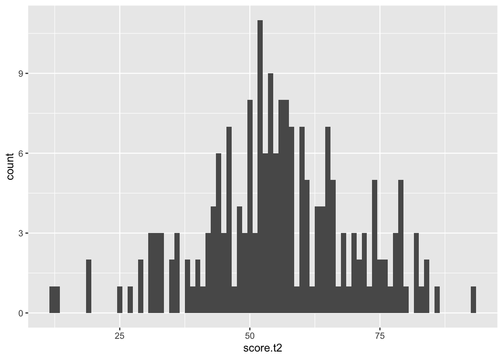

```r
# To identify the row index and data value of the problematic data
outlier_score.t2_index <- which(tutoring_data_1$score.t2 >100)

# To remove the problematic data
# Note, one row of data is removed, with 200 rows remaining
tutoring_data_2 <- tutoring_data_1[-outlier_score.t2_index,]

# To re-examine the attribute, "score.t2" via a plot
ggplot(tutoring_data_2) +
  geom_histogram(mapping=aes(x=score.t2),
                 binwidth=1,
                 bins=count(distinct(tutoring_data_2, score.t2)))
```

```r
## To check the distribution of the categorical data

# To check if each student_ID is unique
# Note, there are 200 unique student_ID and no corrective action is needed
tutoring_data_2 %>%
  group_by(student_ID) %>%
  summarize(total_unique_ID = n_distinct(student_ID))
```

```
##   total_unique_ID
## 1             200
```

```r
# To check for total number of students with and without tutors
# Note, TRUE indicates having a tutor and FALSE indicates not having a tutor
summary(tutoring_data_2$tutoring)
```

```
##  TRUE FALSE
##   100   100
```

## Tasks for Question 1

### Plot average test scores for tutored and non-tutored students at the beginning of the academic year.

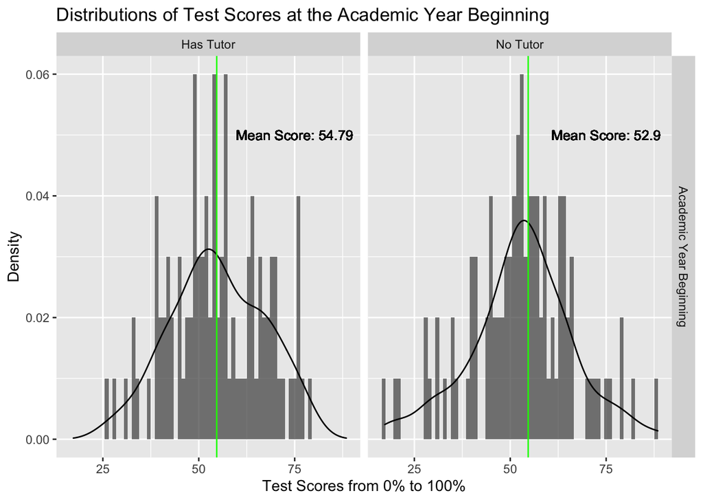

```r
# To calculate the average score.t1 for students with no tutoring
avg.score.t1.no_tutor <- tutoring_data_2 %>%
  filter(tutoring=="FALSE") %>%
  summarise(round(mean(score.t1),2))

# To calculate the average score.t1 for students with tutoring
avg.score.t1.has_tutor <- tutoring_data_2 %>%
  filter(tutoring=="TRUE") %>%
  summarise(round(mean(score.t1),2))

# To calculate the average score.t2 for students with no tutoring
avg.score.t2.no_tutor <- tutoring_data_2 %>%
  filter(tutoring=="FALSE") %>%
  summarise(round(mean(score.t2),2))

# To calculate the average score.t2 for students with tutoring
avg.score.t2.has_tutor <- tutoring_data_2 %>%
  filter(tutoring=="TRUE") %>%
  summarise(round(mean(score.t2),2))

# To transform data frame from wide to long
tutoring_data_long <- tutoring_data_2 %>%
  pivot_longer(score.t1:score.t2, names_to= "term", values_to="term_score")

# To relabel factors in the data set
tutoring_data_long$term <- fct_recode(tutoring_data_long$term,
                                      "Academic Year Beginning" = "score.t1",
                                      "Academic Year End" = "score.t2")
tutoring_data_long$tutoring <- fct_recode(tutoring_data_long$tutoring,
                                          "Has Tutor" = "TRUE",
                                          "No Tutor" = "FALSE")

# Preparation of facet value labels
term_score_by_group <- tutoring_data_long %>%
  group_by(term, tutoring) %>%
  summarise(mean=mean(term_score))

# Preparation of facet text labels
f_label.t1.no.tutor <- filter(tutoring_data_long,
                             term=="Academic Year Beginning",
                             tutoring=="No Tutor")
f_label.t1.has.tutor <- filter(tutoring_data_long,
                             term=="Academic Year Beginning",
                             tutoring=="Has Tutor")
f_label.t2.no.tutor  <- filter(tutoring_data_long,
                             term=="Academic Year End",
                             tutoring=="No Tutor")
f_label.t2.has.tutor <- filter(tutoring_data_long,
                             term=="Academic Year End",
                             tutoring=="Has Tutor")

# To plot the distributions of scores between tutored and non-tutored students at the beginning of the academic year
tutoring_data_long_filtered <- tutoring_data_long %>%
  filter(term=="Academic Year Beginning")

ggplot(tutoring_data_long_filtered) +
  geom_histogram(aes(x=term_score, y=..density..), alpha=0.75, binwidth=1) +
  geom_density(aes(x=term_score, y=..density..)) +
  facet_grid(term~tutoring) +
  geom_vline(data=term_score_by_group,
             mapping=aes(xintercept=mean),
             col="green") +
  geom_text(data=f_label.t1.no.tutor,
            label=paste("Mean Score:", avg.score.t1.no_tutor),
            x=75, y=0.05, size=3.5) +
  geom_text(data=f_label.t1.has.tutor,
            label=paste("Mean Score:", avg.score.t1.has_tutor),
            x=75, y=0.05, size=3.5) +
  labs(title="Distributions of Test Scores at the Academic Year Beginning",
       x=expression("Test Scores from 0% to 100%"),
       y="Density")
```

### Run NHST and Estimation approaches on test scores for the beginning of the academic year.

```r
# To run a NHST approach
t.test(tutoring_data_2$score.t1~tutoring_data_2$tutoring)
```

```
##
##  Welch Two Sample t-test
##
## data:  tutoring_data_2$score.t1 by tutoring_data_2$tutoring
## t = 1.0467, df = 196.54, p-value = 0.2965
## alternative hypothesis: true difference in means between group TRUE and group FALSE is not equal to 0
## 95 percent confidence interval:
##  -1.665720  5.433861
## sample estimates:
##  mean in group TRUE mean in group FALSE
##            54.78753            52.90345
```

```r
# To run an estimation approach
m.avg.score.t1 <- lm(score.t1~tutoring, data=tutoring_data_2)
( m.avg.score.t1.emm <- emmeans(m.avg.score.t1 , ~tutoring))
```

```
##  tutoring emmean   SE  df lower.CL upper.CL
##  TRUE       54.8 1.27 198     52.3     57.3
##  FALSE      52.9 1.27 198     50.4     55.4
##
## Confidence level used: 0.95
```

```r
( m.avg.score.t1.contrast <- confint(pairs(m.avg.score.t1.emm)))
```

```
##  contrast     estimate  SE  df lower.CL upper.CL
##  TRUE - FALSE     1.88 1.8 198    -1.67     5.43
##
## Confidence level used: 0.95
```

```r
# The mean test scores at the beginning of the academic year for tutored students are 54.79, 95% CI [52.30%, 57.30%] and for non-tutored students are 52.90, 95% CI [50.40%, 55.40%]. However, the mean test scores at the beginning of the academic year for tutored and non-tutored students are found not to be significantly different or are similar, Welch t(196.5)=1.05, p=0.30, 95% CI [-1.67%, 5.43%].
```

### Plot average absences for tutored and non-tutored students for the whole academic year.

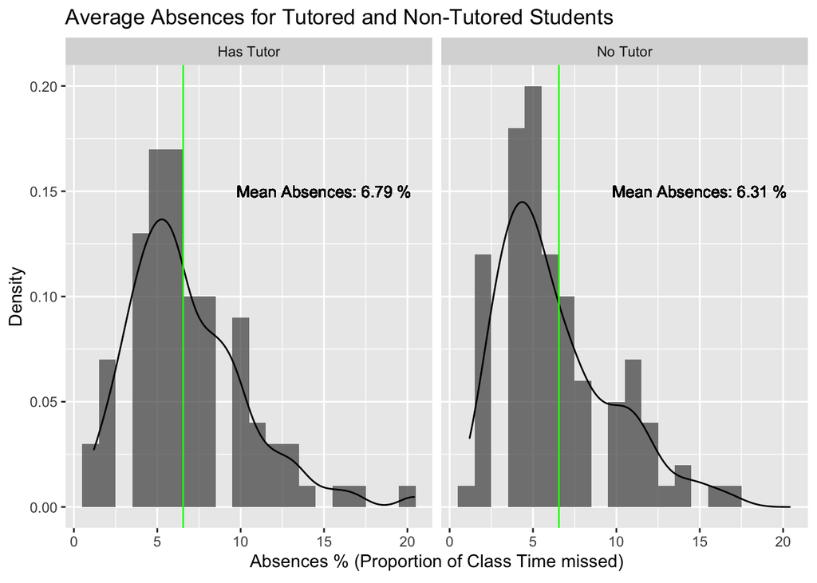

```r
# To calculate the absence for students with no tutoring
avg.absences.no_tutor <- tutoring_data_2 %>%
  filter(tutoring=="FALSE") %>%
  summarise(round(mean(absences),2))

# To calculate the absence for students with tutoring
avg.absences.has_tutor <- tutoring_data_2 %>%
  filter(tutoring=="TRUE") %>%
  summarise(round(mean(absences),2))

# Preparation of facet value labels
avg_absences_by_group <- tutoring_data_long %>%
  group_by(tutoring) %>%
  summarise(mean_absences=mean(absences))

# Preparation of facet text labels
f_label.no.tutor <- filter(tutoring_data_long,
                             tutoring=="No Tutor")
f_label.has.tutor <- filter(tutoring_data_long,
                             tutoring=="Has Tutor")

# To plot the distributions of absences between tutored and non-tutored students at the beginning and end of the academic year
ggplot(tutoring_data_long) +
  geom_histogram(aes(x=absences, y=..density..), alpha=0.75, binwidth=1) +
  geom_density(aes(x=absences, y=..density..)) +
  facet_grid(.~tutoring) +
  geom_vline(data=avg_absences_by_group,
             mapping=aes(xintercept=mean_absences),
             col="green") +
  geom_text(data=f_label.no.tutor,
            label=paste("Mean Absences:", avg.absences.no_tutor, "%"),
            x=15, y=0.15, size=3.5) +
  geom_text(data=f_label.has.tutor,
            label=paste("Mean Absences:", avg.absences.has_tutor, "%"),
            x=15, y=0.15, size=3.5) +
  labs(title="Average Absences for Tutored and Non-Tutored Students",
       x=expression("Absences % (Proportion of Class Time missed)"),
       y="Density")
```

### Run NHST and Estimation approaches on absences for the whole academic year.

```r
# To run a NHST approach
t.test(tutoring_data_2$absences~tutoring_data_2$tutoring)
```

```
##
##  Welch Two Sample t-test
##
## data:  tutoring_data_2$absences by tutoring_data_2$tutoring
## t = 0.98528, df = 197.6, p-value = 0.3257
## alternative hypothesis: true difference in means between group TRUE and group FALSE is not equal to 0
## 95 percent confidence interval:
##  -0.480721  1.440721
## sample estimates:
##  mean in group TRUE mean in group FALSE
##               6.792               6.312
```

```r
# To run an estimation approach
m.avg.absences <- lm(absences~tutoring, data=tutoring_data_2)
( m.avg.absences.emm <- emmeans(m.avg.absences , ~tutoring))
```

```
##  tutoring emmean    SE  df lower.CL upper.CL
##  TRUE       6.79 0.344 198     6.11     7.47
##  FALSE      6.31 0.344 198     5.63     6.99
##
## Confidence level used: 0.95
```

```r
( m.avg.absences.contrast <- confint(pairs(m.avg.absences.emm)))
```

```
##  contrast     estimate    SE  df lower.CL upper.CL
##  TRUE - FALSE     0.48 0.487 198   -0.481     1.44
##
## Confidence level used: 0.95
```

```r
# The mean absences for tutored students are 6.79%, 95% CI [6.11%, 7.47%] and for non-tutored students are 6.31%, 95% CI [5.63%, 6.99%]. However, the mean absences for tutored and non-tutored student are found not to be significantly different or are similar, Welch t(197.6)=0.99, p=0.33, 95% CI [-0.48%, 1.44%].
```

### Plot average test scores for tutored and non-tutored students for the academic year beginning and end.

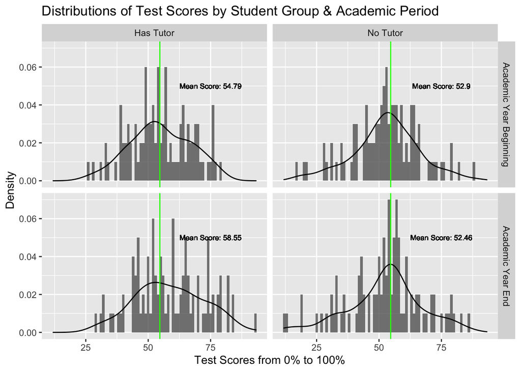

```r
# To plot the distributions of scores between tutored and non-tutored students at the beginning and end of the academic year
ggplot(tutoring_data_long) +
  geom_histogram(aes(x=term_score, y=..density..), alpha=0.75, binwidth=1) +
  geom_density(aes(x=term_score, y=..density..)) +
  facet_grid(term~tutoring) +
  geom_vline(data=term_score_by_group,
             mapping=aes(xintercept=mean),
             col="green") +
  geom_text(data=f_label.t1.no.tutor,
            label=paste("Mean Score:", avg.score.t1.no_tutor),
            x=75, y=0.05, size=2.5) +
  geom_text(data=f_label.t1.has.tutor,
            label=paste("Mean Score:", avg.score.t1.has_tutor),
            x=75, y=0.05, size=2.5) +
  geom_text(data=f_label.t2.no.tutor,
            label=paste("Mean Score:", avg.score.t2.no_tutor),
            x=75, y=0.05, size=2.5) +
  geom_text(data=f_label.t2.has.tutor,
            label=paste("Mean Score:", avg.score.t2.has_tutor),
            x=75, y=0.05, size=2.5) +
  labs(title="Distributions of Test Scores by Student Group & Academic Period",
       x=expression("Test Scores from 0% to 100%"),
       y="Density")
```

### Run NHST and Estimation approaches to test the effect of tutoring on students’ test score improvements.

```r
# To add a new column "improved_score"
tutoring_data_2 <- tutoring_data_2 %>%
  mutate(improved_score=round(score.t2-score.t1,5))

# To run a NHST approach
t.test(tutoring_data_2$improved_score~tutoring_data_2$tutoring)
```

```
##
##  Welch Two Sample t-test
##
## data:  tutoring_data_2$improved_score by tutoring_data_2$tutoring
## t = 5.0811, df = 194.29, p-value = 8.78e-07
## alternative hypothesis: true difference in means between group TRUE and group FALSE is not equal to 0
## 95 percent confidence interval:
##  2.573163 5.837998
## sample estimates:
##  mean in group TRUE mean in group FALSE
##           3.7656263          -0.4399543
```

```r
# NHST approach: The mean improved test score for tutored students is a gain of 3.77. The mean improved test score for non-tutored students is a reduction of 0.44. The mean improved test score is significantly larger for tutored students Welch t(194.3)=5.08, p < 0.0001, with a difference of 4.21.

# To run an estimation approach
m1 <- lm(improved_score~tutoring, data=tutoring_data_2)
( m1.emm <- emmeans(m1, ~tutoring))
```

```
##  tutoring emmean    SE  df lower.CL upper.CL
##  TRUE       3.77 0.585 198     2.61    4.920
##  FALSE     -0.44 0.585 198    -1.59    0.714
##
## Confidence level used: 0.95
```

```r
( m1.contrast <- confint(pairs(m1.emm)))
```

```
##  contrast     estimate    SE  df lower.CL upper.CL
##  TRUE - FALSE     4.21 0.828 198     2.57     5.84
##
## Confidence level used: 0.95
```

```r
# Estimation approach: The mean improved test score for tutored students is 3.77, 95% CI[2.61--4.92]. The mean improved test score for non-tutored students is -0.44, 95% CI[-1.59--0.71]. The mean improved test score for tutored students is larger than non-tutored students by 4.21, 95% CI[2.57--5.84].
```

### Run a Multiple Linear Regression to test the effect of tutoring and absences on students’ test scores.

```r
# To make non-tutored students as the baseline
tutoring_data_2$tutoring <- factor(tutoring_data_2$tutoring,
                                 levels=c("FALSE","TRUE"))

# To check the levels for "tutoring"
levels(tutoring_data_2$tutoring)
```

```
## [1] "FALSE" "TRUE"
```

```r
# Multiple Regression with "tutoring" and "absences" as predictors of "improved_score"
mr.score.tutoring.abs <- lm(improved_score~tutoring + absences,
                           data=tutoring_data_2)
summary(mr.score.tutoring.abs)
```

```
##
## Call:
## lm(formula = improved_score ~ tutoring + absences, data = tutoring_data_2)
##
## Residuals:
##      Min       1Q   Median       3Q      Max
## -14.5498  -3.5452  -0.2211   3.4694  15.7400
##
## Coefficients:
##              Estimate Std. Error t value Pr(>|t|)
## (Intercept)    0.3101     0.9610   0.323    0.747
## tutoringTRUE   4.2626     0.8298   5.137 6.69e-07 ***
## absences      -0.1188     0.1208  -0.984    0.326
## ---
## Signif. codes:  0 '***' 0.001 '**' 0.01 '*' 0.05 '.' 0.1 ' ' 1
##
## Residual standard error: 5.853 on 197 degrees of freedom
## Multiple R-squared:  0.1197, Adjusted R-squared:  0.1107
## F-statistic: 13.39 on 2 and 197 DF,  p-value: 3.525e-06
```

```r
cbind(coef(mr.score.tutoring.abs), confint(mr.score.tutoring.abs))
```

```
##                              2.5 %    97.5 %
## (Intercept)   0.3100852 -1.5850720 2.2052424
## tutoringTRUE  4.2626178  2.6262141 5.8990215
## absences     -0.1188275 -0.3569579 0.1193028
```

```r
# When estimating the effect of both tutoring and absences in the same regression we find that when controlling for other variables, a student who has had tutoring predicts an increase in improved test scores of 4.26 marks (t(197) = 5.14, p<0.001, 95% CI [2.63, 5.90]). However, absences is not found not to be a significant predictor on improved test scores (t(197) = -0.98, p=0.326, 95% CI [-0.36, 0.12]).

# Multiple Regressions with "tutoring" and "absences" as predictors with interactions of "improved_score"
mr.score.tutoring.abs.intr <- lm(improved_score~tutoring * absences,
                           data=tutoring_data_2)
summary(mr.score.tutoring.abs.intr)
```

```
##
## Call:
## lm(formula = improved_score ~ tutoring * absences, data = tutoring_data_2)
##
## Residuals:
##      Min       1Q   Median       3Q      Max
## -14.6208  -3.5477  -0.2268   3.5930  15.7730
##
## Coefficients:
##                       Estimate Std. Error t value Pr(>|t|)
## (Intercept)            0.42453    1.25171   0.339   0.7349
## tutoringTRUE           4.03560    1.79026   2.254   0.0253 *
## absences              -0.13696    0.17517  -0.782   0.4352
## tutoringTRUE:absences  0.03471    0.24235   0.143   0.8863
## ---
## Signif. codes:  0 '***' 0.001 '**' 0.01 '*' 0.05 '.' 0.1 ' ' 1
##
## Residual standard error: 5.868 on 196 degrees of freedom
## Multiple R-squared:  0.1198, Adjusted R-squared:  0.1063
## F-statistic:  8.89 on 3 and 196 DF,  p-value: 1.495e-05
```

```r
# To compare the two models; one without interaction and one with interaction
anova(mr.score.tutoring.abs, mr.score.tutoring.abs.intr)
```

```
## Analysis of Variance Table
##
## Model 1: improved_score ~ tutoring + absences
## Model 2: improved_score ~ tutoring * absences
##   Res.Df    RSS Df Sum of Sq      F Pr(>F)
## 1    197 6749.1
## 2    196 6748.4  1   0.70611 0.0205 0.8863
```

```r
# When we also include an interaction term in the model, the interaction is not a significant predictor (t(196) = 0.14, p = 0.8863) and a model comparison test shows that the overall model fit is not significantly improved (F(1,196) = 0.02, p = 0.8863).
```

# Question 1 (Section 2)

## Average test scores for tutored and non-tutored students at the beginning of the academic year.

From the sample observation of 200 students obtained from a high school which had implemented a buddying system where older students spent time tutoring some of the younger students, 100 students had a tutor while the other 100 students did not have a tutor for the entire academic year.

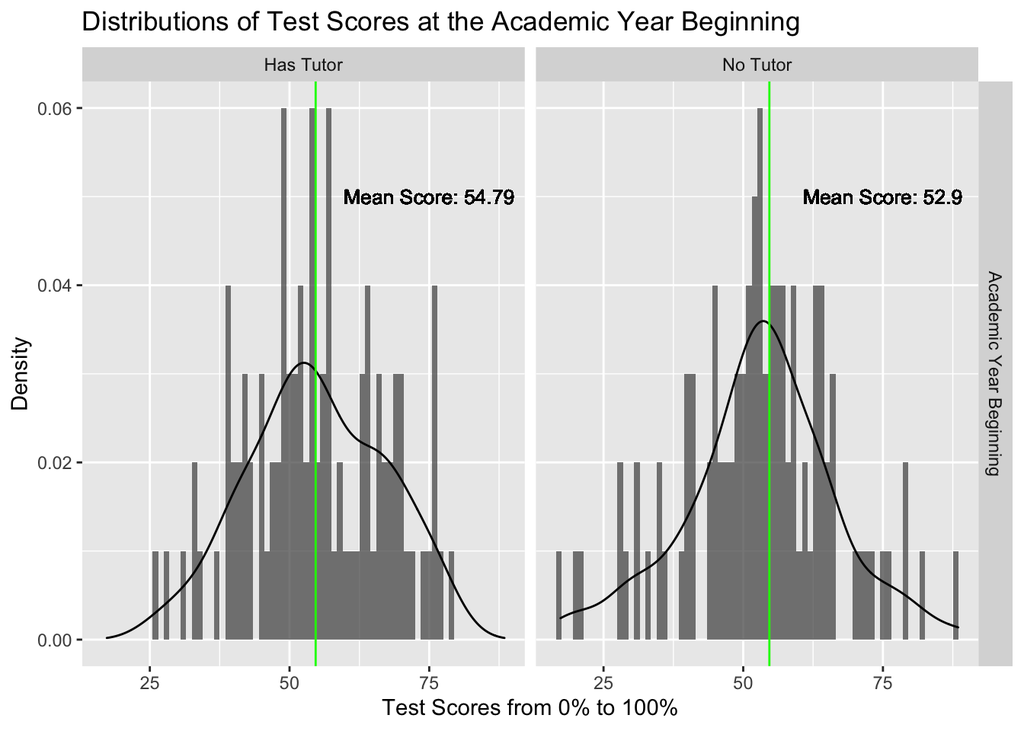

When plotted as distributions, it is observed that the range of test scores of tutored students are less wide and dispersed from the average, while the range of test scores of non-tutored students are more wide and dispersed away from the average.

It is found that the mean test scores at the beginning of the academic year for tutored students are 54.79, 95% CI [52.30%, 57.30%] and for non-tutored students are 52.90, 95% CI [50.40%, 55.40%].

However, the mean test scores at the beginning of the academic year for tutored and non-tutored students are found not to be significantly different or are similar, Welch t(196.5)=1.05, p=0.30, 95% CI [-1.67%, 5.43%].

## Average absences for tutored and non-tutored students for the whole academic year.

For all students, their attendance in regular classes are monitored. Therefore, absences are represented as the proportion of class time missed by students during the whole academic year.

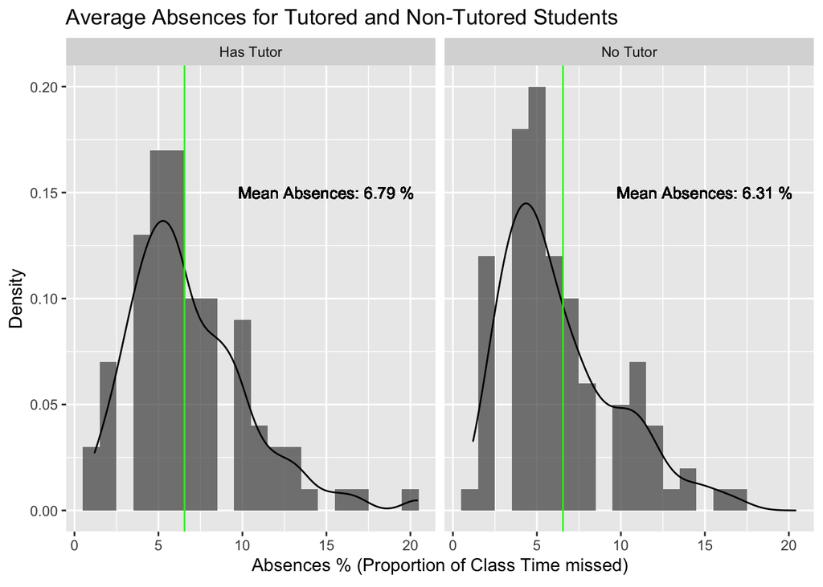

When plotted as distributions, it can be observed that some tutored students registered the highest absences of about 20% in the entire school for the whole academic year.

It is found that the mean absences for tutored students are 6.79%, 95% CI [6.11%, 7.47%] and for non-tutored students are 6.31%, 95% CI [5.63%, 6.99%].

However, the mean absences for tutored and non-tutored student are found not to be significantly different or are similar, Welch t(197.6)=0.99, p=0.33, 95% CI [-0.48%, 1.44%].

## Effect of tutoring on test scores.

The average test scores of the tutored and non-tutored students are calculated for the beginning and end of the academic year. Additionally, the distribution of the test scores are plotted.

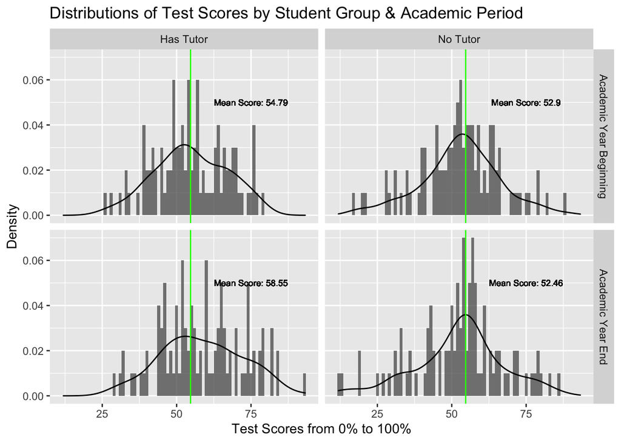

From the plots, it appears that the average test scores for tutored students have improved from 54.79% to 58.55% while for non-tutored students, the average test scores have reduced from 52.90% to 52.46%. To validate this observation, NHST and Estimation approaches are subsequently carried out.

**NHST approach:** The mean improved test score for tutored students is a gain of 3.77. The mean improved test score for non-tutored students is a reduction of 0.44. The mean improved test score is significantly larger for tutored students Welch t(194.3)=5.08, p < 0.0001, with a difference of 4.21.

**Estimation approach:** The mean improved test score for tutored students is 3.77, 95% CI[2.61–4.92]. The mean improved test score for non-tutored students is -0.44, 95% CI[-1.59–0.71]. The mean improved test score for tutored students is larger than non-tutored students by 4.21, 95% CI[2.57–5.84].

Therefore, tutoring is validated to have improved student test scores.

## Effect of tutoring and absences on test scores.

In addition to tutoring, the effect of the rate of absences on test scores is examined separately as an independent variable and interactive term.

**Results from examining the effects of tutoring and absences as independent variables**

When estimating the effect of both tutoring and absences in the same regression we find that when controlling for other variables, a student who has had tutoring predicts an increase in improved test scores of 4.26 marks (t(197) = 5.14, p<0.001, 95% CI [2.63, 5.90]). However, absences is not found not to be a significant predictor on improved test scores (t(197) = -0.98, p=0.326, 95% CI [-0.36, 0.12]).

**Results from examining the effects of tutoring and absences as interaction terms**

When we also include an interaction term in the model, the interaction is not a significant predictor (t(196) = 0.14, p = 0.8863) and a model comparison test shows that the overall model fit is not significantly improved (F(1,196) = 0.02, p = 0.8863).

**Conclusion**

In conclusion, unlike tutoring, the rate of absences is not significant in impacting test scores tutored and non-tutored students.

# Question 2 (Section 1)

## Data Dictionary

Below is a collection of data samples and its description.

| Variable | Description |
| --- | --- |
| Name | Name of beer |
| Style | Style of brew |
| Brewery | Brewery |
| ABV | Alcohol by volume |
| rating | Consumer rating |
| minIBU | Minimum International Bitterness Units |
| maxIBU | Maximum International Bitterness Units |
| Astringency | Level of Astrigency properties |
| Body | Level of Body properties |
| Alcohol | Level of Alcohol properties |
| Bitter | Level of Bitter properties |
| Sweet | Level of Sweet properties |
| Sour | Level of Sour properties |
| Salty | Level of Salty properties |
| Fruits | Level of Fruits properties |
| Hoppy | Level of Hoppy properties |
| Spices | Level of Spices properties |
| Malty | Level of Malty properties |

## Load, View and Factorise data

```r
# To read the data file
beer_data <- read_csv("Craft-Beer_data_set.csv")
# To view the data types
str(beer_data)
```

```
## spec_tbl_df [5,558 × 18] (S3: spec_tbl_df/tbl_df/tbl/data.frame)
##  $ Name       : chr [1:5558] "Amber" "Double Bag" "Long Trail Ale" "Doppelsticke" ...
##  $ Style      : chr [1:5558] "Altbier" "Altbier" "Altbier" "Altbier" ...
##  $ Brewery    : chr [1:5558] "Alaskan Brewing Co." "Long Trail Brewing Co." "Long Trail Brewing Co." "Uerige ObergÃ¤rige Hausbrauerei" ...
##  $ ABV        : num [1:5558] 5.3 7.2 5 8.5 5.3 7.2 6 5.3 5 4.8 ...
##  $ rating     : num [1:5558] 3.65 3.9 3.58 4.15 3.67 3.78 4.1 3.46 3.6 4.1 ...
##  $ minIBU     : num [1:5558] 25 25 25 25 25 25 25 25 25 25 ...
##  $ maxIBU     : num [1:5558] 50 50 50 50 50 50 50 50 50 50 ...
##  $ Astringency: num [1:5558] 13 12 14 13 21 25 22 28 18 25 ...
##  $ Body       : num [1:5558] 32 57 37 55 69 51 45 40 49 35 ...
##  $ Alcohol    : num [1:5558] 9 18 6 31 10 26 13 3 5 4 ...
##  $ Bitter     : num [1:5558] 47 33 42 47 63 44 46 40 37 38 ...
##  $ Sweet      : num [1:5558] 74 55 43 101 120 45 62 58 73 39 ...
##  $ Sour       : num [1:5558] 33 16 11 18 14 9 25 29 22 13 ...
##  $ Salty      : num [1:5558] 0 0 0 1 0 1 1 0 0 1 ...
##  $ Fruits     : num [1:5558] 33 24 10 49 19 11 34 36 21 8 ...
##  $ Hoppy      : num [1:5558] 57 35 54 40 36 51 60 54 37 60 ...
##  $ Spices     : num [1:5558] 8 12 4 16 15 20 4 8 4 16 ...
##  $ Malty      : num [1:5558] 111 84 62 119 218 95 103 97 98 97 ...
##  - attr(*, "spec")=
##   .. cols(
##   ..   Name = col_character(),
##   ..   Style = col_character(),
##   ..   Brewery = col_character(),
##   ..   ABV = col_double(),
##   ..   rating = col_double(),
##   ..   minIBU = col_double(),
##   ..   maxIBU = col_double(),
##   ..   Astringency = col_double(),
##   ..   Body = col_double(),
##   ..   Alcohol = col_double(),
##   ..   Bitter = col_double(),
##   ..   Sweet = col_double(),
##   ..   Sour = col_double(),
##   ..   Salty = col_double(),
##   ..   Fruits = col_double(),
##   ..   Hoppy = col_double(),
##   ..   Spices = col_double(),
##   ..   Malty = col_double()
##   .. )
##  - attr(*, "problems")=<externalptr>
```

```r
# To identify problematic and outlier data
summary(beer_data)
```

```
##      Name              Style             Brewery               ABV             rating
##  Length:5558        Length:5558        Length:5558        Min.   : 0.000   Min.   :1.27
##  Class :character   Class :character   Class :character   1st Qu.: 5.000   1st Qu.:3.59
##  Mode  :character   Mode  :character   Mode  :character   Median : 6.000   Median :3.82
##                                                           Mean   : 6.634   Mean   :3.76
##                                                           3rd Qu.: 7.900   3rd Qu.:4.04
##                                                           Max.   :57.500   Max.   :4.83
##      minIBU          maxIBU        Astringency         Body           Alcohol
##  Min.   : 0.00   Min.   :  0.00   Min.   : 0.00   Min.   :  0.00   Min.   :  0.00
##  1st Qu.:10.00   1st Qu.: 25.00   1st Qu.: 8.00   1st Qu.: 25.00   1st Qu.:  5.00
##  Median :20.00   Median : 35.00   Median :14.00   Median : 38.00   Median : 10.00
##  Mean   :20.72   Mean   : 38.45   Mean   :15.94   Mean   : 42.75   Mean   : 15.98
##  3rd Qu.:25.00   3rd Qu.: 45.00   3rd Qu.:22.00   3rd Qu.: 55.00   3rd Qu.: 20.00
##  Max.   :65.00   Max.   :100.00   Max.   :83.00   Max.   :197.00   Max.   :139.00
##      Bitter           Sweet             Sour            Salty            Fruits
##  Min.   :  0.00   Min.   :  0.00   Min.   :  0.00   Min.   : 0.000   Min.   :  0.00
##  1st Qu.: 13.00   1st Qu.: 27.00   1st Qu.:  9.00   1st Qu.: 0.000   1st Qu.: 10.00
##  Median : 29.00   Median : 49.50   Median : 21.00   Median : 0.000   Median : 28.00
##  Mean   : 34.32   Mean   : 53.63   Mean   : 34.61   Mean   : 1.314   Mean   : 39.38
##  3rd Qu.: 51.00   3rd Qu.: 74.00   3rd Qu.: 44.00   3rd Qu.: 1.000   3rd Qu.: 61.75
##  Max.   :150.00   Max.   :263.00   Max.   :323.00   Max.   :66.000   Max.   :222.00
##      Hoppy            Spices           Malty
##  Min.   :  0.00   Min.   :  0.00   Min.   :  0.00
##  1st Qu.: 14.00   1st Qu.:  4.00   1st Qu.: 33.00
##  Median : 30.00   Median :  9.00   Median : 65.00
##  Mean   : 38.41   Mean   : 17.58   Mean   : 68.59
##  3rd Qu.: 56.00   3rd Qu.: 22.00   3rd Qu.: 99.00
##  Max.   :193.00   Max.   :184.00   Max.   :304.00
```

## Inspect and Clean data

```r
# To select only unique rows
distinct(beer_data)
```

```
## # A tibble: 5,558 × 18
##    Name  Style Brewery   ABV rating minIBU maxIBU Astringency  Body Alcohol Bitter Sweet  Sour Salty
##    <chr> <chr> <chr>   <dbl>  <dbl>  <dbl>  <dbl>       <dbl> <dbl>   <dbl>  <dbl> <dbl> <dbl> <dbl>
##  1 Amber Altb… Alaska…   5.3   3.65     25     50          13    32       9     47    74    33     0
##  2 Doub… Altb… Long T…   7.2   3.9      25     50          12    57      18     33    55    16     0
##  3 Long… Altb… Long T…   5     3.58     25     50          14    37       6     42    43    11     0
##  4 Dopp… Altb… Uerige…   8.5   4.15     25     50          13    55      31     47   101    18     1
##  5 Scur… Altb… Off Co…   5.3   3.67     25     50          21    69      10     63   120    14     0
##  6 Slei… Altb… Ninkas…   7.2   3.78     25     50          25    51      26     44    45     9     1
##  7 Stic… Altb… Uerige…   6     4.1      25     50          22    45      13     46    62    25     1
##  8 Okto… Altb… Widmer…   5.3   3.46     25     50          28    40       3     40    58    29     0
##  9 Sout… Altb… Southa…   5     3.6      25     50          18    49       5     37    73    22     0
## 10 Copp… Altb… The Ol…   4.8   4.1      25     50          25    35       4     38    39    13     1
## # … with 5,548 more rows, and 4 more variables: Fruits <dbl>, Hoppy <dbl>, Spices <dbl>,
## #   Malty <dbl>
```

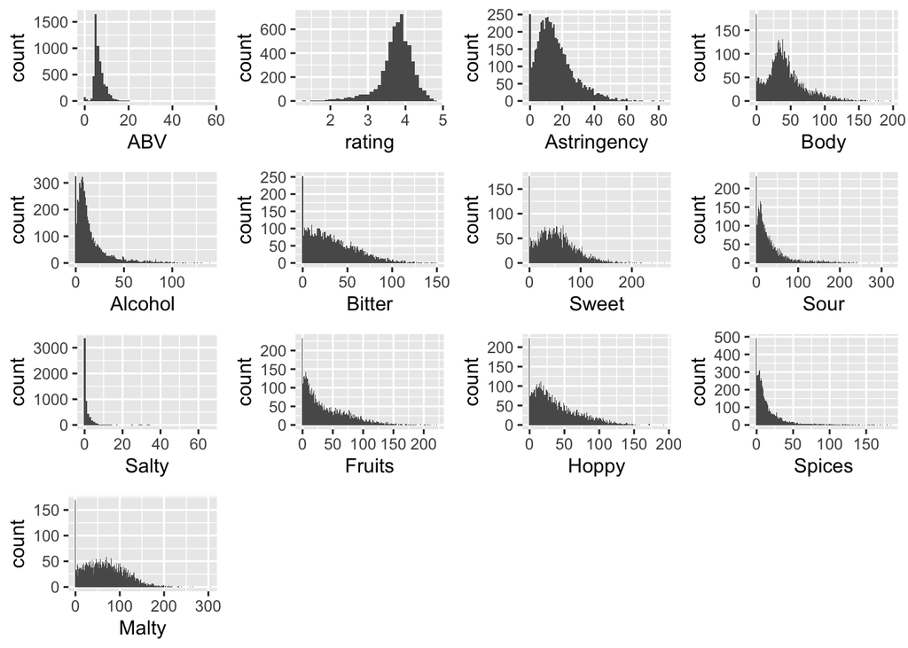

```r
# To examine the attribute, "ABV" via a plot
examine_1 <- ggplot(beer_data) +
  geom_histogram(mapping=aes(x=ABV),
                 binwidth=1,
                 bins=count(distinct(beer_data, ABV)))


# To examine the attribute, "rating" via a plot
examine_2 <- ggplot(beer_data) +
  geom_histogram(mapping=aes(x=rating),
                 binwidth=0.1,
                 bins=count(distinct(beer_data, rating)))

# To examine the attribute, "Astringency" via a plot
examine_3 <- ggplot(beer_data) +
  geom_histogram(mapping=aes(x=Astringency),
                 binwidth=1,
                 bins=count(distinct(beer_data, Astringency)))

# To examine the attribute, "Body" via a plot
examine_4 <- ggplot(beer_data) +
  geom_histogram(mapping=aes(x=Body),
                 binwidth=1,
                 bins=count(distinct(beer_data, Body)))

# To examine the attribute, "Alcohol" via a plot
examine_5 <- ggplot(beer_data) +
  geom_histogram(mapping=aes(x=Alcohol),
                 binwidth=1,
                 bins=count(distinct(beer_data, Alcohol)))

# To examine the attribute, "Bitter" via a plot
examine_6 <- ggplot(beer_data) +
  geom_histogram(mapping=aes(x=Bitter),
                 binwidth=1,
                 bins=count(distinct(beer_data, Bitter)))

# To examine the attribute, "Sweet" via a plot
examine_7 <- ggplot(beer_data) +
  geom_histogram(mapping=aes(x=Sweet),
                 binwidth=1,
                 bins=count(distinct(beer_data, Sweet)))

# To examine the attribute, "Sour" via a plot
examine_8 <- ggplot(beer_data) +
  geom_histogram(mapping=aes(x=Sour),
                 binwidth=1,
                 bins=count(distinct(beer_data, Sour)))

# To examine the attribute, "Salty" via a plot
examine_9 <- ggplot(beer_data) +
  geom_histogram(mapping=aes(x=Salty),
                 binwidth=1,
                 bins=count(distinct(beer_data, Salty)))

# To examine the attribute, "Fruits" via a plot
examine_10 <- ggplot(beer_data) +
  geom_histogram(mapping=aes(x=Fruits),
                 binwidth=1,
                 bins=count(distinct(beer_data, Fruits)))

# To examine the attribute, "Hoppy" via a plot
examine_11 <- ggplot(beer_data) +
  geom_histogram(mapping=aes(x=Hoppy),
                 binwidth=1,
                 bins=count(distinct(beer_data, Hoppy)))

# To examine the attribute, "Spices" via a plot
examine_12 <- ggplot(beer_data) +
  geom_histogram(mapping=aes(x=Spices),
                 binwidth=1,
                 bins=count(distinct(beer_data, Spices)))

# To examine the attribute, "Malty" via a plot
examine_13 <- ggplot(beer_data) +
  geom_histogram(mapping=aes(x=Malty),
                 binwidth=1,
                 bins=count(distinct(beer_data, Malty)))

# To arrange all the plots in a single grid for ease of data examination
# Note, plots look fine, no further actions required
grid.arrange(examine_1, examine_2, examine_3, examine_4,
             examine_5, examine_6, examine_7, examine_8,
             examine_9, examine_10, examine_11, examine_12,
             examine_13, ncol=4)
```

## Tasks for Question 2A

### Categorise the beers in the dataset by the specified categories based on the “Styles” variable.

```r
# To categorise beer containing specific strings / category identifiers
# Note, in addition to "Pale Ale" being classified under the category of "Pale", there are specific beer from "Mild Ale" and "Strong Ale" which contain "Pale" and are categorised as "Pale" as well
beer_data$Category <- case_when(
    grepl("IPA ", beer_data$Style) ~ "IPA",
    grepl("Lager ", beer_data$Style) ~ "Lager",
    grepl("Porter ", beer_data$Style) ~ "Porter",
    grepl("Stout ", beer_data$Style) ~ "Stout",
    grepl("Wheat ", beer_data$Style) ~ "Wheat",
    grepl(" Pale", beer_data$Style) ~ "Pale",
    grepl("Pale ", beer_data$Style) ~ "Pale",
    grepl("Pilsner ", beer_data$Style) ~ "Pilsner",
    grepl("Bock ", beer_data$Style) ~ "Bock",
    TRUE ~ "Other"
)

# To check on the frequency of Category
sort(table(beer_data$Category), decreasing = TRUE)
```

```
##
##   Other   Lager   Stout     IPA   Wheat  Porter    Bock    Pale Pilsner
##    2608     900     400     350     350     300     250     250     150
```

```r
# To check on the frequency of Category in percentages %
sort(round(prop.table(table(beer_data$Category)),4)*100, decreasing = TRUE)
```

```
##
##   Other   Lager   Stout     IPA   Wheat  Porter    Bock    Pale Pilsner
##   46.92   16.19    7.20    6.30    6.30    5.40    4.50    4.50    2.70
```

```r
# To convert the table frequency of Category (%) into a dataframe
category <- sort(round(prop.table(table(beer_data$Category)),4)*100,
                 decreasing = TRUE)
category_prop <- data.frame(category)
colnames(category_prop) <- c("Category","Proportion (%)")

# To create a new data frame with "Category" and "rating" only
beer_data_df <- data.frame(beer_data)
rating_by_category <- beer_data_df[c("Category","rating")]

# To convert "Category" into a factor
rating_by_category$Category <- as.factor(rating_by_category$Category)

# To calculate average rating by "Category"
category_mean_rating <- rating_by_category %>%
  dplyr::group_by(Category) %>%
  dplyr::summarise(Avg_Rating=round(mean(rating),2))

# To join the two newly created tables by using merge() function
category_joined <- merge(x=category_prop,category_mean_rating,by="Category")

# To sort the aggregated table for Category by average rating by proportion %
category_sorted <- category_joined[rev(order(category_joined$Avg_Rating)),]

# To display table frequency of Category (%) in a simple table
category_sorted %>%
    knitr::kable(caption= "Overview of Beer Category by Proportion (%) and Average Rating",
               digits=2,
               align="ccc",
               col.names = c("Category",
                             "Proportion (%)",
                             "Average Rating"))
```

Overview of Beer Category by Proportion (%) and Average Rating

|  | Category | Proportion (%) | Average Rating |
| --- | --- | --- | --- |
| 2 | IPA | 6.30 | 4.03 |
| 8 | Stout | 7.20 | 4.00 |
| 7 | Porter | 5.40 | 3.97 |
| 4 | Other | 46.92 | 3.81 |
| 1 | Bock | 4.50 | 3.81 |
| 5 | Pale | 4.50 | 3.77 |
| 9 | Wheat | 6.30 | 3.71 |
| 6 | Pilsner | 2.70 | 3.69 |
| 3 | Lager | 16.19 | 3.36 |

### Calculate the mean rating and 95% confidence intervals of the rating within each category using a linear model.

```r
# To update "Category" to a factor
beer_data$Category <- factor(beer_data$Category)

# To confirm "Category" has been updated to a factor
str(beer_data$Category)
```

```
##  Factor w/ 9 levels "Bock","IPA","Lager",..: 4 4 4 4 4 4 4 4 4 4 ...
```

```r
# To update and verify the levels of "Category", to make "Other" as the baseline
beer_data$Category <- factor(beer_data$Category,
                                  levels=c("Other",
                                           "IPA",
                                           "Lager",
                                           "Porter",
                                           "Stout",
                                           "Wheat",
                                           "Pale",
                                           "Pilsner",
                                           "Bock"))
levels(beer_data$Category)
```

```
## [1] "Other"   "IPA"     "Lager"   "Porter"  "Stout"   "Wheat"   "Pale"    "Pilsner" "Bock"
```

```r
# To create a simple linear model to predict rating by Category
lm.ratings.cat <- lm(rating~Category, data=beer_data)
summary(lm.ratings.cat)
```

```
##
## Call:
## lm(formula = rating ~ Category, data = beer_data)
##
## Residuals:
##      Min       1Q   Median       3Q      Max
## -2.23714 -0.19740  0.03095  0.26291  1.01848
##
## Coefficients:
##                  Estimate Std. Error t value Pr(>|t|)
## (Intercept)      3.807136   0.007776 489.624  < 2e-16 ***
## CategoryIPA      0.222293   0.022605   9.834  < 2e-16 ***
## CategoryLager   -0.450047   0.015351 -29.317  < 2e-16 ***
## CategoryPorter   0.160264   0.024209   6.620 3.93e-11 ***
## CategoryStout    0.191914   0.021323   9.000  < 2e-16 ***
## CategoryWheat   -0.095936   0.022605  -4.244 2.23e-05 ***
## CategoryPale    -0.033016   0.026290  -1.256 0.209238
## CategoryPilsner -0.116802   0.033342  -3.503 0.000463 ***
## CategoryBock     0.004384   0.026290   0.167 0.867563
## ---
## Signif. codes:  0 '***' 0.001 '**' 0.01 '*' 0.05 '.' 0.1 ' ' 1
##
## Residual standard error: 0.3971 on 5549 degrees of freedom
## Multiple R-squared:  0.1975, Adjusted R-squared:  0.1963
## F-statistic: 170.7 on 8 and 5549 DF,  p-value: < 2.2e-16
```

```r
(  lm.ratings.cat.emm <- emmeans(lm.ratings.cat, ~Category)  )
```

```
##  Category emmean       SE   df lower.CL upper.CL
##  Other     3.807 0.007776 5549    3.792    3.822
##  IPA       4.029 0.021225 5549    3.988    4.071
##  Lager     3.357 0.013236 5549    3.331    3.383
##  Porter    3.967 0.022926 5549    3.922    4.012
##  Stout     3.999 0.019855 5549    3.960    4.038
##  Wheat     3.711 0.021225 5549    3.670    3.753
##  Pale      3.774 0.025114 5549    3.725    3.823
##  Pilsner   3.690 0.032422 5549    3.627    3.754
##  Bock      3.812 0.025114 5549    3.762    3.861
##
## Confidence level used: 0.95
```

```r
# To sort Category by the estimated marginal mean ratings
beer_data$Category <- factor(beer_data$Category,
                                  levels=c("Lager",
                                           "Pilsner",
                                           "Wheat",
                                           "Pale",
                                           "Other",
                                           "Bock",
                                           "Porter",
                                           "Stout",
                                           "IPA"))
levels(beer_data$Category)
```

```
## [1] "Lager"   "Pilsner" "Wheat"   "Pale"    "Other"   "Bock"    "Porter"  "Stout"   "IPA"
```

```r
# To recreate the simple linear model with the newly sorted Category by emmeans
lm.ratings.cat <- lm(rating~Category, data=beer_data)
(  lm.ratings.cat.emm <- emmeans(lm.ratings.cat, ~Category)  )
```

```
##  Category emmean       SE   df lower.CL upper.CL
##  Lager     3.357 0.013236 5549    3.331    3.383
##  Pilsner   3.690 0.032422 5549    3.627    3.754
##  Wheat     3.711 0.021225 5549    3.670    3.753
##  Pale      3.774 0.025114 5549    3.725    3.823
##  Other     3.807 0.007776 5549    3.792    3.822
##  Bock      3.812 0.025114 5549    3.762    3.861
##  Porter    3.967 0.022926 5549    3.922    4.012
##  Stout     3.999 0.019855 5549    3.960    4.038
##  IPA       4.029 0.021225 5549    3.988    4.071
##
## Confidence level used: 0.95
```

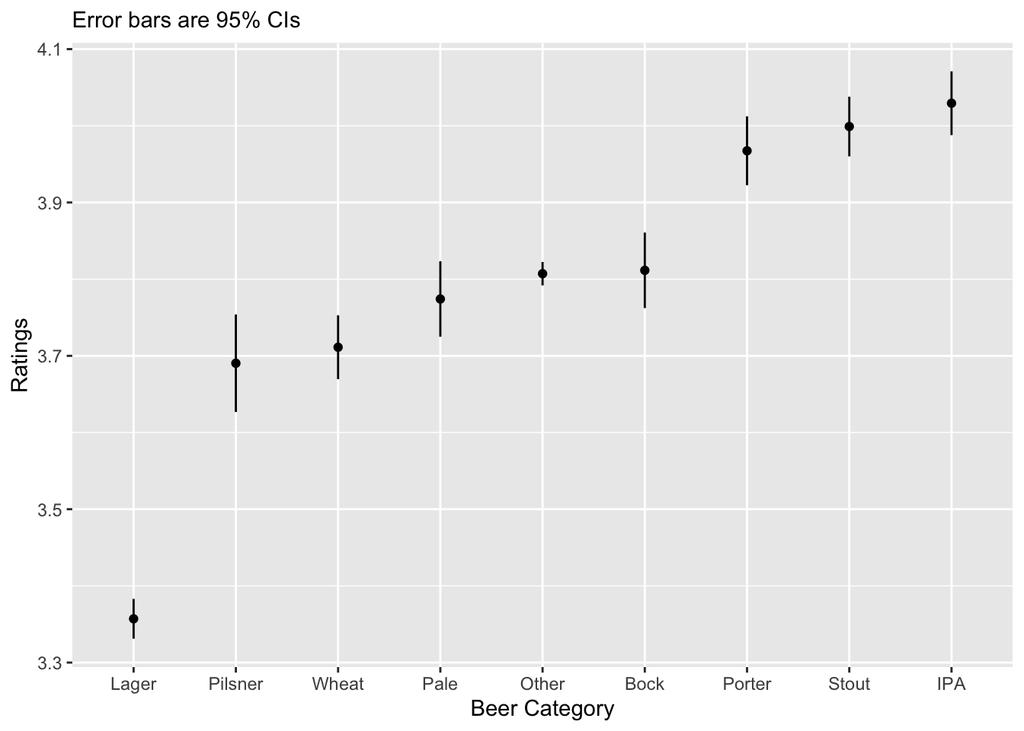

```r
# To plot the ratings by Category
(  plot.lm.ratings.cat.emm <- ggplot(summary(lm.ratings.cat.emm),
                                     aes(x=Category,
                                         y=emmean,
                                         ymin=lower.CL,
                                         ymax=upper.CL)) +
    geom_point(col="black") +
    geom_linerange(col="black") +
    labs(x="Beer Category",
         y="Ratings",
         subtitle="Error bars are 95% CIs")   )
```

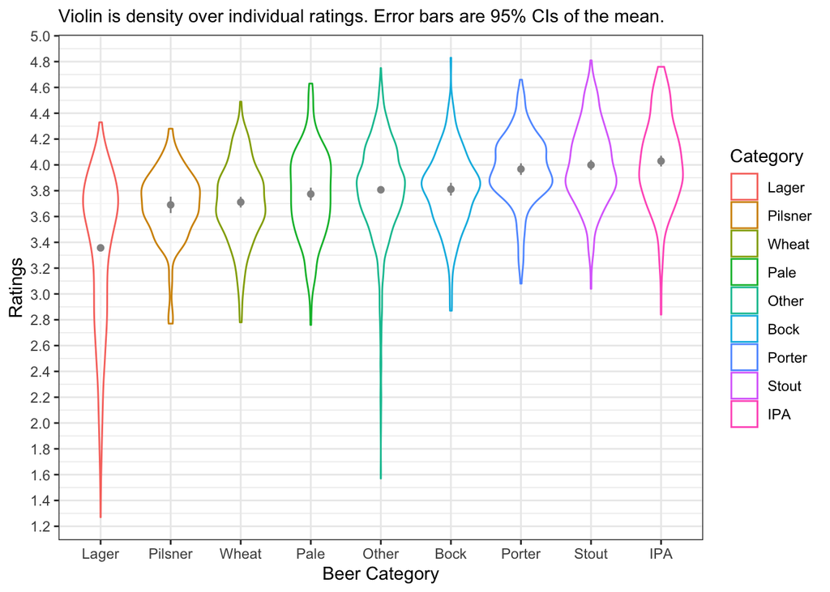

```r
# To plot the distribution of the ratings within each category and to plot the mean ratings and 95% confidence interval of each category.
plot.lm.ratings.cat.emm +
  geom_violin(data=beer_data,
              mapping=aes(x=Category, y=rating, ymin=NULL, ymax=NULL, color=Category),
              alpha=0.5) +
  labs(subtitle="Violin is density over individual ratings. Error bars are 95% CIs of the mean.") +
  scale_y_continuous(breaks=seq(1,5,by=0.2)) +
  theme_bw()
```

## Tasks for Question 2B

### Categorise beer into Higher or Lower ABV.

```r
# To categorise beer into high and lower ABV category as per the UK High Strength Beer Duty
beer_data$ABV_category <- case_when(beer_data$ABV>7.5 ~ "Higher ABV",TRUE~"Lower ABV")

# To view the count of higher and lower ABV
count(beer_data$ABV_category)
```

```
##            x freq
## 1 Higher ABV 1487
## 2  Lower ABV 4071
```

### Calculate average rating of beer with Higher and Lower ABV.

```r
# To create a new table showing Higher and Lower ABV, total count
abv_table <- beer_data %>%
  group_by(ABV_category) %>%
  dplyr::summarise(total=n(), proportion=round(n()/nrow(beer_data)*100,2))

# To display table of Higher or Lower ABV in a simple table
abv_table %>%
    knitr::kable(caption= "Classification of beer into Higher and Lower ABV",
               digits=2,
               align="ccc",
               col.names = c("ABV Category",
                             "Total",
                             "Proportion (%)"))
```

Classification of beer into Higher and Lower ABV

| ABV Category | Total | Proportion (%) |
| --- | --- | --- |
| Higher ABV | 1487 | 26.75 |
| Lower ABV | 4071 | 73.25 |

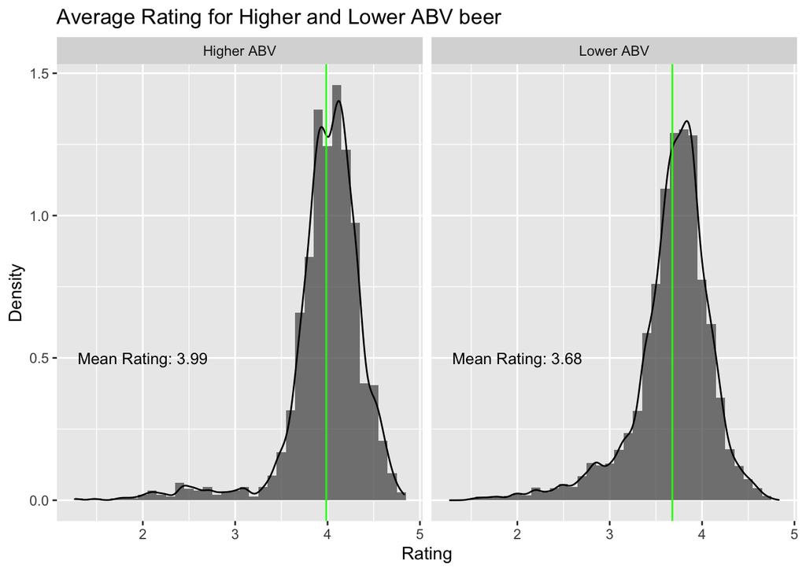

```r
# To calculate the ratings for higher ABV
avg.rating.higher.abv <- beer_data %>%
  filter(ABV_category=="Higher ABV") %>%
  dplyr::summarise(round(mean(rating),2))

# To calculate the ratings for lower ABV
avg.rating.lower.abv <- beer_data %>%
  filter(ABV_category=="Lower ABV") %>%
  dplyr::summarise(round(mean(rating),2))

# Preparation of facet value labels
avg_rating_by_abv_cat <- beer_data %>%
  group_by(ABV_category) %>%
  dplyr::summarise(mean_rating=mean(rating))

# Preparation of facet text labels
f_label.avg.higher.abv <- filter(avg_rating_by_abv_cat,
                             ABV_category=="Higher ABV")

f_label.avg.lower.abv <- filter(avg_rating_by_abv_cat,
                             ABV_category=="Lower ABV")

# To plot the distributions of rating between higher and lower ABV beer
ggplot(beer_data) +
  geom_histogram(aes(x=rating, y=..density..), alpha=0.75, binwidth=0.1) +
  geom_density(aes(x=rating, y=..density..)) +
  facet_grid(.~ABV_category) +
  geom_vline(data=avg_rating_by_abv_cat,
             mapping=aes(xintercept=mean_rating),
             col="green") +
  geom_text(data=f_label.avg.higher.abv,
            label=paste("Mean Rating:", avg.rating.higher.abv),
            x=2, y=0.5, size=3.5) +
  geom_text(data=f_label.avg.lower.abv,
            label=paste("Mean Rating:", avg.rating.lower.abv),
            x=2, y=0.5, size=3.5) +
  labs(title="Average Rating for Higher and Lower ABV beer",
       x=expression("Rating"),
       y="Density")
```

### Run NHST and Estimation approaches to test the effect of Higher and Lower ABV on rating.

```r
# To run a NHST approach
t.test(beer_data$rating~beer_data$ABV_category)
```

```
##
##  Welch Two Sample t-test
##
## data:  beer_data$rating by beer_data$ABV_category
## t = 24.366, df = 2684.8, p-value < 2.2e-16
## alternative hypothesis: true difference in means between group Higher ABV and group Lower ABV is not equal to 0
## 95 percent confidence interval:
##  0.2836626 0.3333133
## sample estimates:
## mean in group Higher ABV  mean in group Lower ABV
##                 3.986194                 3.677706
```

```r
# NHST approach: The mean rating for Higher ABV is 3.99 and for Lower ABV is 3.68. The mean rating is significantly larger for Higher ABV Welch t(2684.8)=24.37, p < 0.0001, with a difference of 0.31.

# To run an estimation approach
m_abv <- lm(rating~ABV_category, data=beer_data)
( m_abv.emm <- emmeans(m_abv, ~ABV_category))
```

```
##  ABV_category emmean       SE   df lower.CL upper.CL
##  Higher ABV    3.986 0.010928 5556    3.965    4.008
##  Lower ABV     3.678 0.006605 5556    3.665    3.691
##
## Confidence level used: 0.95
```

```r
( m_abv_contrast <- confint(pairs(m_abv.emm)))
```

```
##  contrast               estimate     SE   df lower.CL upper.CL
##  Higher ABV - Lower ABV    0.308 0.0128 5556    0.283    0.334
##
## Confidence level used: 0.95
```

```r
# Estimation approach: The mean rating for Higher ABV is 3.99, 95% CI[3.97–4.00]. The mean rating for Lower ABV is 3.68, 95% CI[3.67–3.69]. The mean rating for Higher ABV is larger than Lower ABV by 0.31, 95% CI[0.28–0.33].
```

### Run multiple linear regression for the effect of ABV and Sweet on rating.

```r
# To run a multiple linear regression
mlr.by.abv.sweet <- lm(rating~ABV + Sweet, data=beer_data)
summary(mlr.by.abv.sweet)
```

```
##
## Call:
## lm(formula = rating ~ ABV + Sweet, data = beer_data)
##
## Residuals:
##     Min      1Q  Median      3Q     Max
## -3.6966 -0.1555  0.0461  0.2330  1.0837
##
## Coefficients:
##              Estimate Std. Error t value Pr(>|t|)
## (Intercept) 3.2660727  0.0153742  212.44   <2e-16 ***
## ABV         0.0588357  0.0023316   25.23   <2e-16 ***
## Sweet       0.0019367  0.0001639   11.81   <2e-16 ***
## ---
## Signif. codes:  0 '***' 0.001 '**' 0.01 '*' 0.05 '.' 0.1 ' ' 1
##
## Residual standard error: 0.4014 on 5555 degrees of freedom
## Multiple R-squared:  0.1789, Adjusted R-squared:  0.1786
## F-statistic: 605.3 on 2 and 5555 DF,  p-value: < 2.2e-16
```

```r
cbind(coef(mlr.by.abv.sweet), confint(mlr.by.abv.sweet))
```

```
##                              2.5 %      97.5 %
## (Intercept) 3.266072731 3.23593325 3.296212208
## ABV         0.058835653 0.05426476 0.063406543
## Sweet       0.001936738 0.00161537 0.002258107
```

```r
# When estimating the effect of both ABV and Sweet in the same regression we find that when controlling for other variables, a 1 unit increase in ABV predicts 0.05884 additional rating (t(5555) = 25.23, p<0.001, 95% CI [0.05426, 0.06341]) and an increase in 1 unit of Sweet predicts 0.001937 additional rating (t(5555) = 11.81, p<0.001, 95% CI [0.001615, 0.002258]).

# To run a multiple linear regression with an interaction effect
mlr.by.abv.sweet.intr <- lm(rating~ABV * Sweet, data=beer_data)
summary(mlr.by.abv.sweet.intr)
```

```
##
## Call:
## lm(formula = rating ~ ABV * Sweet, data = beer_data)
##
## Residuals:
##     Min      1Q  Median      3Q     Max
## -4.1763 -0.1567  0.0455  0.2331  1.0866
##
## Coefficients:
##               Estimate Std. Error t value Pr(>|t|)
## (Intercept)  3.189e+00  2.433e-02 131.055  < 2e-16 ***
## ABV          7.009e-02  3.598e-03  19.478  < 2e-16 ***
## Sweet        3.448e-03  4.033e-04   8.550  < 2e-16 ***
## ABV:Sweet   -1.997e-04  4.869e-05  -4.101 4.18e-05 ***
## ---
## Signif. codes:  0 '***' 0.001 '**' 0.01 '*' 0.05 '.' 0.1 ' ' 1
##
## Residual standard error: 0.4009 on 5554 degrees of freedom
## Multiple R-squared:  0.1814, Adjusted R-squared:  0.181
## F-statistic: 410.3 on 3 and 5554 DF,  p-value: < 2.2e-16
```

```r
cbind(coef(mlr.by.abv.sweet.intr), confint(mlr.by.abv.sweet.intr))
```

```
##                                   2.5 %        97.5 %
## (Intercept)  3.1886692461  3.1409715134  3.2363669788
## ABV          0.0700855819  0.0630316312  0.0771395326
## Sweet        0.0034480150  0.0026574678  0.0042385622
## ABV:Sweet   -0.0001996505 -0.0002950955 -0.0001042054
```

```r
# To compare models without and with interaction effect
anova(mlr.by.abv.sweet, mlr.by.abv.sweet.intr)
```

```
## Analysis of Variance Table
##
## Model 1: rating ~ ABV + Sweet
## Model 2: rating ~ ABV * Sweet
##   Res.Df    RSS Df Sum of Sq      F    Pr(>F)
## 1   5555 895.21
## 2   5554 892.51  1    2.7022 16.816 4.178e-05 ***
## ---
## Signif. codes:  0 '***' 0.001 '**' 0.01 '*' 0.05 '.' 0.1 ' ' 1
```

```r
# When we also include an interaction term in the model, the interaction is a significant predictor (t(5554) = -4.10, p<0.001) and a model comparison test shows that the overall model fit is significantly improved (F(1,5554) = 16.82, p<0.001). Note that the t-test and F-test return the same value. There is minimal multicollinearity.

vif(mlr.by.abv.sweet)
```

```
##      ABV    Sweet
## 1.192036 1.192036
```

```r
vif(mlr.by.abv.sweet.intr)
```

```
##       ABV     Sweet ABV:Sweet
##  2.847000  7.233917 11.235226
```

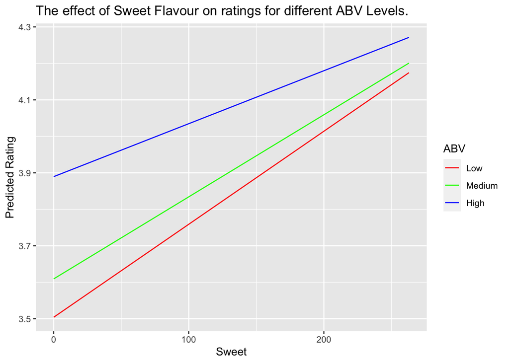

```r
# The full model shows high VIF scores for both main effects and the interaction term. However, VIF scores for the main effects model are all below 2, showing that there is little multicollinearity between the predictor variables and the high VIF scores for the full model are due to the structural multicollinearity caused by the interaction term.

preds.sweet.intr <- tibble(ABV = rep(quantile(beer_data$ABV,
                                                  c(0.1, 0.5, 0.9)), 2), #c(0.1, 0.5, 0.9) is where we want to predict for 3 different values of ABV, a low, a medium and a high ABV. So, we used the quantile function to take the beer_data$ABV, so 0.1 is the 10% quantile of the ABV, 0.5 is the 50% quantile of the ABV and 0.9 is the 90% quantile of ABV.
                    Sweet = c(rep(min(beer_data$Sweet), 3),
                                   rep(max(beer_data$Sweet), 3)))

preds.sweet.intr <- mutate(preds.sweet.intr,
                            rating.hat = predict(mlr.by.abv.sweet.intr,
                                                 preds.sweet.intr),
                            ABV = factor(ABV))

ggplot(preds.sweet.intr) +
  geom_line(aes(x = Sweet, y = rating.hat, colour = ABV)) +
  ylab("Predicted Rating") + scale_colour_manual(labels = c("Low", "Medium" , "High"), values = c("red", "green" , "blue")) +
  labs(title="The effect of Sweet Flavour on ratings for different ABV Levels.")
```

```r
# The results of the full model indicate that there is a significant interaction between ABV and Sweet when predicting ratings. The figure helps to demonstrate that for ABV of low, medium and high, increasing sweetness levels in beer predict higher ratings. Specifically, increasing sweetness levels for beer with low ABV predicts a bigger increase in ratings than for beer with high ABV.
```

### Run multiple linear regression for the effect of ABV and Malty on rating.

```r
# To run a multiple linear regression
mlr.by.abv.malty <- lm(rating~ABV + Malty, data=beer_data)
summary(mlr.by.abv.malty)
```

```
##
## Call:
## lm(formula = rating ~ ABV + Malty, data = beer_data)
##
## Residuals:
##     Min      1Q  Median      3Q     Max
## -4.1243 -0.1523  0.0413  0.2236  1.0658
##
## Coefficients:
##              Estimate Std. Error t value Pr(>|t|)
## (Intercept) 3.2523665  0.0163191 199.298  < 2e-16 ***
## ABV         0.0667503  0.0021896  30.485  < 2e-16 ***
## Malty       0.0009487  0.0001238   7.663 2.13e-14 ***
## ---
## Signif. codes:  0 '***' 0.001 '**' 0.01 '*' 0.05 '.' 0.1 ' ' 1
##
## Residual standard error: 0.4043 on 5555 degrees of freedom
## Multiple R-squared:  0.1671, Adjusted R-squared:  0.1668
## F-statistic: 557.3 on 2 and 5555 DF,  p-value: < 2.2e-16
```

```r
cbind(coef(mlr.by.abv.malty), confint(mlr.by.abv.malty))
```

```
##                                 2.5 %      97.5 %
## (Intercept) 3.2523665091 3.2203746585 3.284358360
## ABV         0.0667503129 0.0624577980 0.071042828
## Malty       0.0009486502 0.0007059559 0.001191345
```

```r
# When estimating the effect of both ABV and Malty in the same regression we find that when controlling for other variables, a 1 unit increase in ABV predicts 0.06675 additional rating (t(5555) = 30.49, p<0.001, 95% CI [0.06246, 0.07104]) and an increase in 1 unit of Malty predicts 0.0009487 additional rating (t(5555) = 7.66, p<0.001, 95% CI [0.0007060, 0.001191]).

# To run a multiple linear regression with interaction effect
mlr.by.abv.malty.intr <- lm(rating~ABV * Malty, data=beer_data)
summary(mlr.by.abv.malty.intr)
```

```
##
## Call:
## lm(formula = rating ~ ABV * Malty, data = beer_data)
##
## Residuals:
##     Min      1Q  Median      3Q     Max
## -3.4392 -0.1513  0.0429  0.2279  1.0478
##
## Coefficients:
##               Estimate Std. Error t value Pr(>|t|)
## (Intercept)  3.351e+00  2.547e-02 131.601  < 2e-16 ***
## ABV          5.237e-02  3.590e-03  14.587  < 2e-16 ***
## Malty       -5.863e-04  3.281e-04  -1.787    0.074 .
## ABV:Malty    2.139e-04  4.236e-05   5.049 4.57e-07 ***
## ---
## Signif. codes:  0 '***' 0.001 '**' 0.01 '*' 0.05 '.' 0.1 ' ' 1
##
## Residual standard error: 0.4034 on 5554 degrees of freedom
## Multiple R-squared:  0.1709, Adjusted R-squared:  0.1705
## F-statistic: 381.7 on 3 and 5554 DF,  p-value: < 2.2e-16
```

```r
cbind(coef(mlr.by.abv.malty.intr), confint(mlr.by.abv.malty.intr))
```

```
##                                   2.5 %       97.5 %
## (Intercept)  3.3512296311  3.3013079361 3.401151e+00
## ABV          0.0523664944  0.0453287900 5.940420e-02
## Malty       -0.0005862561 -0.0012294861 5.697383e-05
## ABV:Malty    0.0002139100  0.0001308626 2.969575e-04
```

```r
# To compare models without and with interaction effect
anova(mlr.by.abv.malty, mlr.by.abv.malty.intr)
```

```
## Analysis of Variance Table
##
## Model 1: rating ~ ABV + Malty
## Model 2: rating ~ ABV * Malty
##   Res.Df    RSS Df Sum of Sq      F    Pr(>F)
## 1   5555 908.10
## 2   5554 903.95  1    4.1499 25.497 4.571e-07 ***
## ---
## Signif. codes:  0 '***' 0.001 '**' 0.01 '*' 0.05 '.' 0.1 ' ' 1
```

```r
# When we also include an interaction term in the model, the interaction is a significant predictor (t(5554) = 5.05, p<0.001) and a model comparison test shows that the overall model fit is significantly improved (F(1,5554) = 25.50, p<0.001). Note that the t-test and F-test return the same value. There is minimal multicollinearity.

vif(mlr.by.abv.malty)
```

```
##      ABV    Malty
## 1.036336 1.036336
```

```r
vif(mlr.by.abv.malty.intr)
```

```
##       ABV     Malty ABV:Malty
##  2.798014  7.311804 10.282331
```

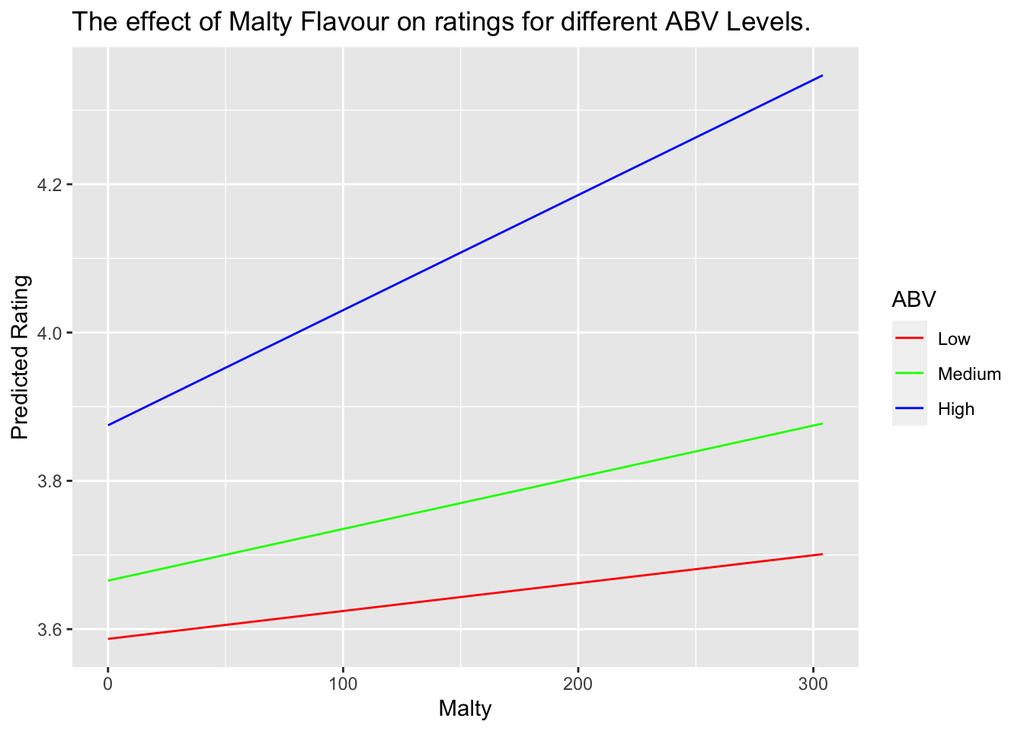

```r
# The full model shows high VIF scores for both main effects and the interaction term. However, VIF scores for the main effects model are all below 2, showing that there is little multicollinearity between the predictor variables and the high VIF scores for the full model are due to the structural multicollinearity caused by the interaction term.

preds.malty.intr <- tibble(ABV = rep(quantile(beer_data$ABV,
                                                  c(0.1, 0.5, 0.9)), 2), #c(0.1, 0.5, 0.9) is where we want to predict for 3 different values of ABV, a low, a medium and a high ABV. So, we used the quantile function to take the beer_data$ABV, so 0.1 is the 10% quantile of the ABV, 0.5 is the 50% quantile of the ABV and 0.9 is the 90% quantile of ABV.
                    Malty = c(rep(min(beer_data$Malty), 3),
                                   rep(max(beer_data$Malty), 3)))

preds.malty.intr <- mutate(preds.malty.intr,
                            rating.hat = predict(mlr.by.abv.malty.intr,
                                                 preds.malty.intr),
                            ABV = factor(ABV))

ggplot(preds.malty.intr) +
  geom_line(aes(x = Malty, y = rating.hat, colour = ABV)) +
  ylab("Predicted Rating") + scale_colour_manual(labels = c("Low", "Medium" , "High"), values = c("red", "green" , "blue")) + labs(title="The effect of Malty Flavour on ratings for different ABV Levels.")
```

```r
# The results of the full model indicate that there is a significant interaction between ABV and Malty when predicting ratings. The figure helps to demonstrate that for ABV of low, medium and high, increasing malty levels in beer predict higher ratings. Specifically, increasing malty levels for beer with high ABV predicts a bigger increase in ratings than for beer with low ABV.
```

# Question 2 (Section 2)

## Proportion and popularity of the categories of beer.

From the data of 5,558 types of beer, each is categorised into “IPA”, “Lager”, “Porter”, “Stout”, “Wheat”, “Pale”, “Pilsner”, “Bock”, and where no category mentioned is applicable, it will be categorised as “Other”. The proportion of the types of beer by category, and the average rating for each category are calculated below.

Overview of Beer Category by Proportion (%) and Average Rating

|  | Category | Proportion (%) | Average Rating |
| --- | --- | --- | --- |
| 2 | IPA | 6.30 | 4.03 |
| 8 | Stout | 7.20 | 4.00 |
| 7 | Porter | 5.40 | 3.97 |
| 4 | Other | 46.92 | 3.81 |
| 1 | Bock | 4.50 | 3.81 |
| 5 | Pale | 4.50 | 3.77 |
| 9 | Wheat | 6.30 | 3.71 |
| 6 | Pilsner | 2.70 | 3.69 |
| 3 | Lager | 16.19 | 3.36 |

## Plot distribution of the individual ratings, and average ratings for each category of beer.

To better visualise the different popularity of beer categories, from the data of 5,558 types of beer, a violin plot is made showing the distribution of ratings within each category, and the average rating of each category is calculated to a 95% confidence intervals.

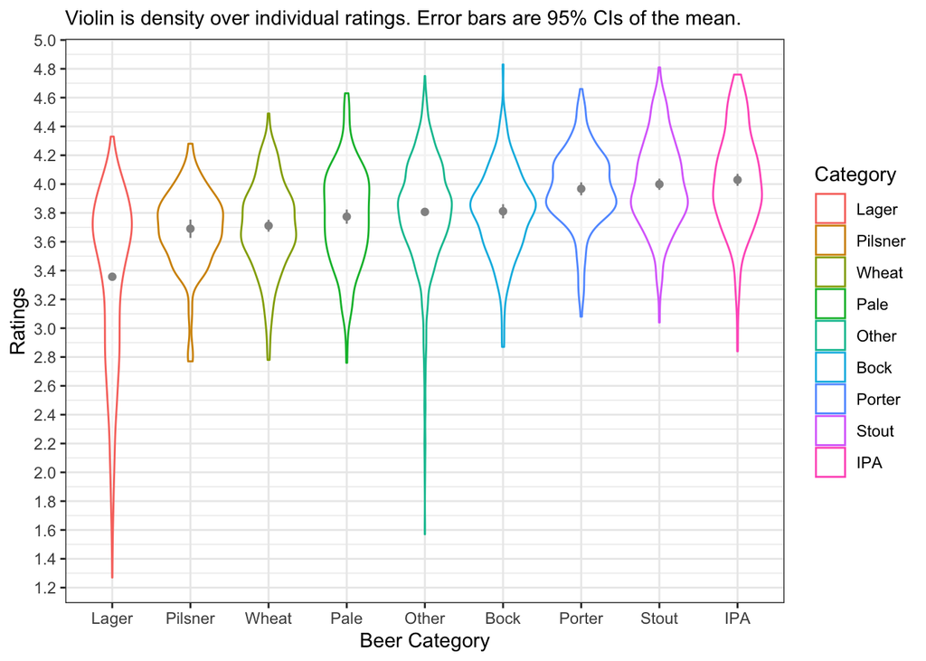

Each point represents the average rating per category, and is joined by a 95% confidence intervals. In ascending order, “Lager” has the lowest average rating of between 3.3 to 3.4, and gradually moving up to the last in the order is “IPA” with the highest average rating of between 4.0 to 4.1.

As noted, “Other” and “Lager” make up the largest proportions. With more data available, the model is able to determine the average ratings of these categories more confidently than other categories thereby, returning visibly, the shortest 95% confidence intervals for these points.

Denoted by the shape of violins are distribution of ratings within each category for 5,558 types of beer examined. It is observed that most violins except “Other” and “Lager”, have short bodies which imply that the range of ratings are narrow, and have less extreme ratings in these categories.

Additionally, the wider the shape of the violin, the more concentrated the ratings are at a specific rating. From the graph, “Lager” is visibly the slimmest violin which may imply that consumers generally have mixed ratings and reviews about this particular category of beer.

## Average rating for beer with Higher and Lower ABV.

To examine if a beer receives a different rating if it has a Higher or Lower ABV, all 5,558 types of beer are classified into Higher or Lower ABV. As defined by the High Strength Beer Duty of the UK where, beer exceeding 7.5% ABV is classified as Higher ABV while beer with 7.5% ABV and below is classified as Lower ABV.

Classification of beer into Higher and Lower ABV

| ABV Category | Total | Proportion (%) |
| --- | --- | --- |
| Higher ABV | 1487 | 26.75 |
| Lower ABV | 4071 | 73.25 |

From the data, 1,487 or 26.75% types of beer are classified as Higher ABV, and 4,071 or 73.25% are classified as Lower ABV. Thereafter, their average rating is calculated and plotted.

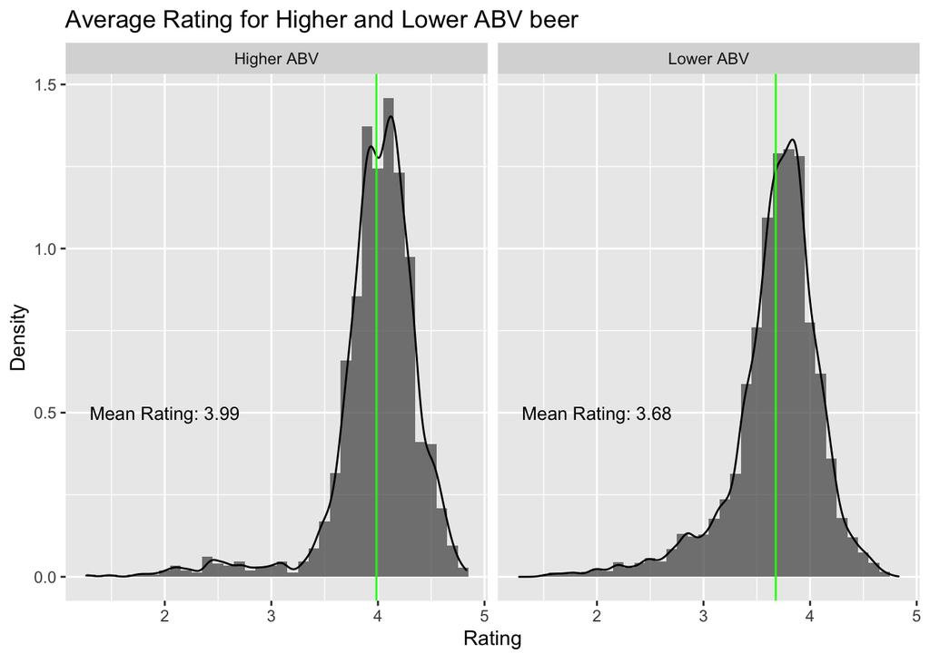

It is found that the mean rating for beer with Higher ABV is 3.99, 95% CI[3.97–4.00]. The mean rating for beer with Lower ABV is 3.68, 95% CI[3.67–3.69]. The mean rating is significantly larger for Higher ABV Welch t(2684.8)=24.37, p < 0.0001, with a difference of 0.31.

## Effects of ABV and Sweet flavour on beer ratings.

**Results from examining the effects on beer ratings, of ABV and Sweet flavour as independent variables**

When estimating the effect of both ABV and Sweet in the same regression we find that when controlling for other variables, a 1 unit increase in ABV predicts 0.05884 additional rating (t(5555) = 25.23, p<0.001, 95% CI [0.05426, 0.06341]) and an increase in 1 unit of Sweet predicts 0.001937 additional rating (t(5555) = 11.81, p<0.001, 95% CI [0.001615, 0.002258]).

**Results from examining the effects on beer ratings, of ABV and Sweet flavour as interactive terms**

When we also include an interaction term in the model, the interaction is a significant predictor (t(5554) = -4.10, p<0.001) and a model comparison test shows that the overall model fit is significantly improved (F(1,5554) = 16.82, p<0.001). Therefore, the model should include interaction terms with ABV and Sweet. Note that the t-test and F-test return the same value. There is minimal multicollinearity.

**Results from examining the reliability of ABV and Sweet flavour as simultaneous predictors**

The full model shows high VIF scores for both main effects and the interaction term. However, VIF scores for the main effects model are all below 2, showing that there is little multicollinearity between the predictor variables and the high VIF scores for the full model are due to the structural multicollinearity caused by the interaction term.

Therefore, the ABV and Sweet flavour can be used simultaneously as predictors for beer ratings.

## Effects of ABV and Malty flavour on beer ratings.

**Results from examining the effects on beer ratings, of ABV and Malty flavour as independent variables**

When estimating the effect of both ABV and Malty in the same regression we find that when controlling for other variables, a 1 unit increase in ABV predicts 0.06675 additional rating (t(5555) = 30.49, p<0.001, 95% CI [0.06246, 0.07104]) and an increase in 1 unit of Malty predicts 0.0009487 additional rating (t(5555) = 7.66, p<0.001, 95% CI [0.0007060, 0.001191]).

**Results from examining the effects on beer ratings, of ABV and Malty flavour as interactive terms**

When we also include an interaction term in the model, the interaction is a significant predictor (t(5554) = 5.05, p<0.001) and a model comparison test shows that the overall model fit is significantly improved (F(1,5554) = 25.50, p<0.001). Therefore, the model should include interaction terms with ABV and Malty. Note that the t-test and F-test return the same value. There is minimal multicollinearity.

**Results from examining the reliability of ABV and Malty flavour as simultaneous predictors**

The full model shows high VIF scores for both main effects and the interaction term. However, VIF scores for the main effects model are all below 2, showing that there is little multicollinearity between the predictor variables and the high VIF scores for the full model are due to the structural multicollinearity caused by the interaction term.

Therefore, the ABV and Malty flavour can be used simultaneously as predictors for beer ratings.

## Conclusion for the effect of Sweet, Malty and ABV on maximising beer ratings for the company.

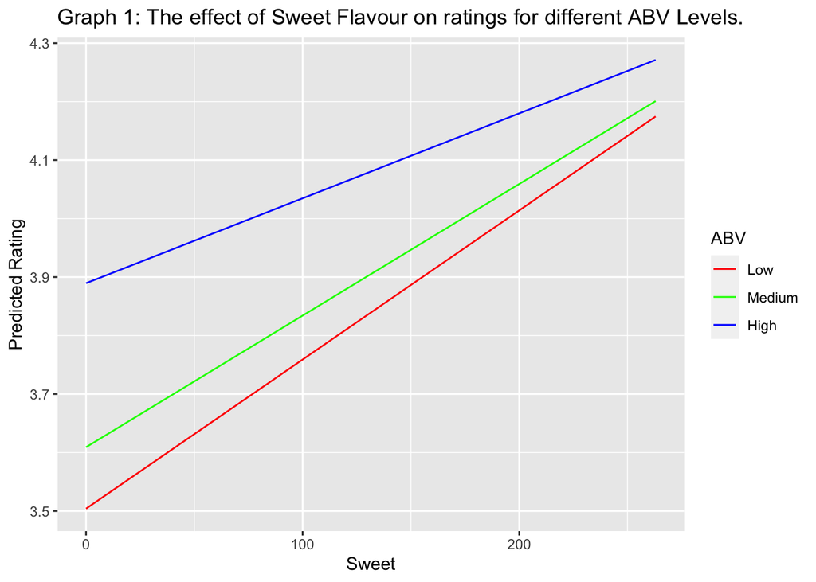

From Graph 1, it indicates that there is a significant interaction between ABV and Sweet when predicting ratings. The figure helps to demonstrate that for ABV of low, medium and high, increasing sweetness levels in beer predict higher ratings. Specifically, increasing sweetness levels for beer with low ABV predicts a bigger increase in ratings than for beer with high ABV.

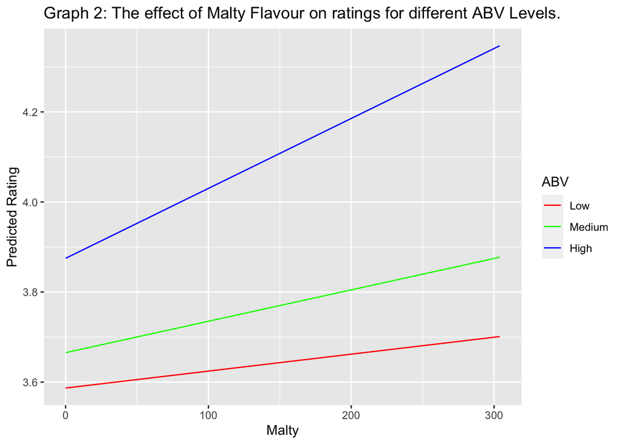

From Graph 2, it indicates that there is a significant interaction between ABV and Malty when predicting ratings. The figure helps to demonstrate that for ABV of low, medium and high, increasing malty levels in beer predict higher ratings. Specifically, increasing malty levels for beer with high ABV predicts a bigger increase in ratings than for beer with low ABV.

**Conclusion**

Therefore, to maximise ratings, the company should focus on increasing sweetness levels for beer with low ABV while increasing malty levels for beer with high ABV.